# STAT340 Exam 1, Fall 2022

Jeffrey

10/17/2022

## Instructions

Update the “author” and “date” fields in the header and complete the exercises below. When you have completed the exam, knit the document, and submit **both the HTML and RMD** files to Canvas.

**Reminder:** exams turned in more than three hours after starting the exam or after the close of the exam window at 3pm on Wednesday October 19th **will not** be accepted. If you wish to be careful, you may want to make a point to knit your document every so often while completing the exam.

You **may not** discuss this exam with any person other than the instructor and the TAs until after the exam has closed (i.e., after the quiz is no longer accessible on Canvas). You may use any and all course materials, including lecture notes, textbooks, other readings, previous homeworks, and the built-in R documentation. You **may not** use any resources not linked to by either the canvas page, lecture notes or the course webpage.

Violation of these restrictions, such as discussing the exam with other students or searching for solutions online, will result in a zero on the exam and will be reported to the Office of Student Conduct.

## Problem 1: Working with Random Variables

Let’s warm up with an easy one. The following questions are about random variables.

### Part a: Generating from a Poisson distribution

Use `rpois` to generate a vector of 100 draws from a Poisson random variable with rate parameter $\lambda = 3.14$ and compute the mean of the resulting vector of random variables.

```r
vec <- rpois(100, lambda = 3.14)
mean(vec)
```

```
## [1] 3.37
```

### Part b: Creating a histogram

Create a histogram of the data generated in part (a) above. Add two vertical lines to your plot:

-one in black, indicating the true population mean $\lambda=3.14$, and -another in red, indicating the observed mean of your sample generated in part (a).

You may use either `ggplot2` or the built-in R plotting functions to create this plot, whichever you prefer.

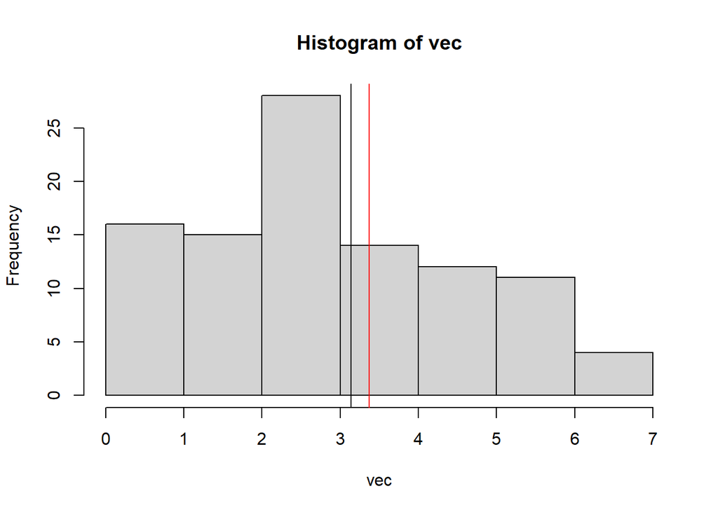

```r
hist(vec)
abline(v = 3.14, col = 'black')
abline(v = mean(vec), col = 'red')
```

### Part c: Applying the Poisson to physics

The Poisson distribution is a popular choice of distribution for modeling the number of particles detected per unit time in physics experiments. Suppose that we model the number of neutrinos arriving at a detector in a second as being distributed as a Poisson random variable with rate parameter $\lambda=100$. Use `ppois` to compute the probability that **at least** $100$ neutrinos arrive at our detector in a one-second experiment.

```r
1 - ppois(100, 100)
```

```
## [1] 0.4734378
```

### Part d: Generating from a normal

Write R code to generate 10,000 ($10^4$) standard normal random variables. How many of these random variables fall within one standard deviation of the mean? Two standard deviations of the mean? Three?

```r
normals <- rnorm(1e4)
sum(normals >= -1 & normals <= 1)
```

```
## [1] 6845
```

```r
sum(normals >= -2 & normals <= 2)
```

```
## [1] 9539
```

```r
sum(normals >= -3 & normals <= 3)
```

```
## [1] 9968
```

### Part e: maximum of exponentials

Implement a function `rmaxexp` that takes two arguments, `n` and `m`, where both `n` and `m` are positive integers and returns `n` independent copies of the following random variable:
$$Z = \operatorname{max}_{i \in \{1,2,\dots,m\} } X_i,$$

where $X_1,X_2,\dots,X_m$ are independent draws from an exponential distribution with rate parameter $1$.

You may assume that both `n` and `m` are positive integers, so there is no need to do any error checking, and there is no need to worry about the case where `n=0` or `m=0`.

```r
rmaxexp <- function(n, m) {
       # TODO: code goes here
       # Hint:
       # Create a length-n vector v and
       # repeat the following n times, storing results in the entries of v:
       # first generate m Exp(1) random variables,
       # THEN find their maximum.

       v <- rep(0, n)
       for (i in 1:n) {
              v[i] <- max(rexp(m))
       }

       return (v)
}
```

## Problem 2: Estimating a Probability Using Monte Carlo

Consider the following game: we give each of $100$ people a unique number $1,2,\dots,100$, and we label each of $100$ chairs with the numbers 1 through 100 (so that each chair has a unique number from $1,2,\dots,100$). Now, we randomly assign people to chairs. Let $p_{100}$ be the probability that *no person* is sitting in a chair that matches their number. Let’s use Monte Carlo simulation to estimate $p_{100}$.

### Part a: implement the experiment

Implement a function `random_seating`, which takes no arguments and returns a Boolean. The function should simulate the experiment described above and return a Boolean encoding whether or not the experiment “succeeded” in assigning all 100 people to a seat that *doesn’t* match their number. That is, your function should run the “seating” experiment described above and return `TRUE` if no person’s number matches their seat and `FALSE` otherwise.

**Hint:** assigning each of the 100 people to a seat is equivalent to randomly shuffling the sequence `1:100`, i.e., `c(1,2,3,...,100)`. Then it just remains to check whether the $i$-th person ended up sitting in the $i$-th seat for any `i=1,2,3,...,100`, which can be done with a simple comparison with a well-chosen vector.

```r
random_seating <- function() {
       # TODO: write code that randomly assigns 100 people to 100 seats
       # TODO: check if any person ended up in the seat matching their number.
       # If not, return TRUE. If so, return FALSE.

       seating <- sample(seq(1:100), size = 100, replace = FALSE);
       for (i in 1:100) {
              if (i == seating[i]) {
                     return (FALSE)
              }
       }
       return (TRUE)

}
```

### Part b: estimating $p_{100}$

Use your function `random_seating` to implement a Monte Carlo simulation and estimate $p_{100}$. Your simulation should use at least $1000$ Monte Carlo iterates. You are free to choose this number to be larger if you wish, but be careful that you don’t choose it so large that your file takes too long to knit! **Hint:** start with a much smaller number of Monte Carlo iterates (e.g., 10 or 100), and increase it only once you are confident that your code is working.

```r
# TODO: Monte Carlo code goes here.

# TODO: don't forget to include code that actually evaluates your answer!
# Something like (uncomment this next line if you want)
# estimate_of_p100 <- ESTIMATE_GOES_HERE

N <- 1e4
success <- 0
for (i in 1:N) {
       if (random_seating()) {
              success <- success + 1
       }
}
success / N
```

```
## [1] 0.3657
```

## Problem 3: The inverse trick

Consider a cumulative distribution

$$F(t) = \begin{cases}
0 &\mbox{ if } t \le 0 \\
\frac{1}{2} + \frac{1}{\pi} \operatorname{arcsin}(2t-1) &\mbox{ if } 0 < t \le 1 \\
1 &\mbox{ if } t > 1.
\end{cases}$$

and suppose that the random variable $X$ is distributed according to this CDF, so that $\Pr[ X \le t ] = F(t)$ for any $t \in \mathbb{R}$.

**Reminder:** $\operatorname{arcsin} x$ is the *inverse sine* of $x$, meaning, the number $\theta$ such that $\operatorname{sin} \theta = x$, defined for all $x \in [-1,1]$.

### Part a: Implement $F(t)$.

Write a function `examCDF` that takes a single argument `t` and returns $F(t)$ as defined in the equation above. You may assume that `t` is a numeric, so there is no need to perform any error checking.

**Hint:** `asin(t)` will compute the arc-sin (i.e., inverse of the sine function) in R.

**Second hint:** you can verify that your function is correct by checking that it agrees with the function $F(t)$ above. For example, check that `examCDF(2)` returns $1$, `examCDF(-1)` returns $0$, etc.

```r
examCDF <- function(t) {
       if (t <= 0) {return (0)}
       if (t > 0 & t <= 1) {return (1/2 + (1 / pi) * asin(2 * t - 1))}
       if (t > 1) {return (1)}
}
```

### Part b: take a derivative!

Derive the density of $X$ by… deriving! Take the derivative of $F(t)$ to establish the density $f(t)$. Implement this function as `examdensity`, a function that takes a single argument `t` and returns $f(t)$.

**Hint:**
$$\frac{d}{dt} \operatorname{arcsin}(2t-1) = \frac{1}{\sqrt{t(1-t)}}.$$

```r
# Range
examdensity <- function(t) {
       if (t <= 0) {return (0)}
       if (t > 0 & t <= 1) {return (1 / sqrt(t * (1 - t)))}
       if (t > 1) {return (0)}
}
```

### Part c: inverting a CDF

Invert the CDF $F(t)$. That is, find the function $F^{-1}(t)$ such that
$$F( F^{-1} (t)) = t$$
for all $0 < t < 1$.

Implement it in R as a function `examCDFinv`, which takes one argument, `t`. You may assume `t` is a numeric strictly between `0.0` and `1.0`.

You must perform the inversion analytically (i.e., determine a function in terms of $t$). Inverting the CDF numerically with `solve()` or similar functions in R is not allowed.

**Hint:** Be careful! Invert the CDF $F(t)$, not the density $f(t)$. Bear in mind that the arcsine (i.e., `asin` in R) is the inverse of the sine function (i.e., `sin` in R), and vice versa.

```r
examCDFinv <- function(t) {
       return ((sin(pi * (t - 1/2)) + 1) / 2)
}
```

### Part d : Generating random variables

Use your function `examCDFinv` to generate 1000 independent random variables with distribution $F$.

Make a *normalized* histogram of their distribution. Use your function `examdensity` to overlay the density function of these random variables on the plot (plotted as a solid line in whatever color you prefer). You may use the built-in R plotting functions or the `ggplot2` plotting functions, whichever you prefer. If you did not complete part (b), you may simply include the histogram with no overlaid density for partial credit.

**Hint:** Note that this part of the problem is a free way for you to check that your implementations above worked, provided you were able to complete part (b)– if you plot that density, the histogram should resemble it.

**Second hint:** be careful that you are normalizing the histogram! If not, the density and histogram will be on very different scales and the plot won’t make sense. See the `freq` argument to the `hist` function in R.

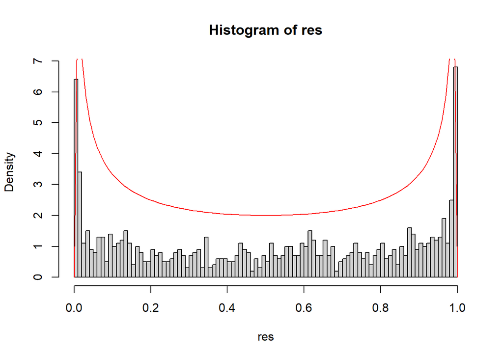

```r
dist <- runif(1000)
res <- sapply(dist, examCDFinv)
hist(res, breaks = 100, freq = FALSE)
x <- seq(1,100,0.1);
curve(Vectorize(examdensity)(x), add=TRUE, col='red' );
```